# Applications of Nonlinear Systems

MATH 341 — Notes 13

University of Scranton

2026-10-04

# Goals

## What We Will Cover

1. **Lotka–Volterra** predator–prey model — periodic orbits, conserved quantity, the exceptional center case
2. **Competing species** — coexistence vs. competitive exclusion depending on competition strength
3. **SIR epidemic model** — disease-free equilibrium, the basic reproduction number $R_0$
4. **Chemical kinetics** — law of mass action, consecutive reactions, asymptotically stable node
5. **Nonlinear pendulum** — centers vs. saddles, energy conservation, the separatrix
6. **Van der Pol oscillator** — unstable origin, attracting limit cycle, self-sustained oscillations

**Note**

**Section 5.3** of (Logan 2015).

**Tip**

New vocabulary: predator–prey, conserved quantity, competitive exclusion, basic reproduction number $R_0$, law of mass action, separatrix (pendulum), limit cycle.

# Lotka–Volterra Predator–Prey

## The Model

Let $x(t)$ = prey, $y(t)$ = predator. Parameters $a,b,c,d > 0$.

$$x' = ax - bxy, \qquad y' = -cy + dxy. \tag{5.14--5.15}$$

| Term | Meaning |
| --- | --- |
| $ax$ | Prey grow exponentially without predators |
| $-bxy$ | Predation reduces prey |
| $-cy$ | Predators die without prey |
| $dxy$ | Predators grow by consuming prey |

**Critical points:** $(0,0)$ and $\left(\dfrac{c}{d},\dfrac{a}{b}\right)$.

## Jacobian Analysis

$$J(x,y)=\begin{pmatrix}a-by & -bx \\ dy & -c+dx\end{pmatrix}.$$

**At $(0,0)$:** eigenvalues $a>0$ and $-c<0$ $\implies$ **unstable saddle**.

**At $\left(\dfrac{c}{d},\dfrac{a}{b}\right)$:**
$$J=\begin{pmatrix}0 & -bc/d \\ da/b & 0\end{pmatrix}, \quad \lambda^2+ac=0, \quad \lambda=\pm i\sqrt{ac}.$$

**Purely Imaginary Eigenvalues — Exceptional Case**

Linearization gives a **center**. We cannot conclude whether the nonlinear system has a center or a spiral from linearization alone.

**Resolution:** find the conserved quantity $H(x,y) = dx - c\ln x + by - a\ln y$. Its level curves are the orbits — they are **closed**, confirming the nonlinear system also has a center.

## Conserved Quantity and Periodic Orbits

Divide $y'$ by $x'$ and separate variables:

$$\frac{-c+dx}{x}\,dx + \frac{a-by}{y}\,dy = 0.$$

Integrating:

$$\boxed{H(x,y) = dx - c\ln x + by - a\ln y = \text{const.}}$$

- Level curves of $H$ are **closed curves** encircling $(c/d,\, a/b)$.
- Both populations oscillate **periodically** — the classic boom–bust cycle.
- The orbit period depends on the energy level (orbit size).

**Note**

Volterra used this model to explain why fishing *reductions* during WWI increased the *proportion* of predatory fish (sharks) in the Adriatic — because removing both species equally shifts the oscillation average.

## Phase Portrait and Time Series

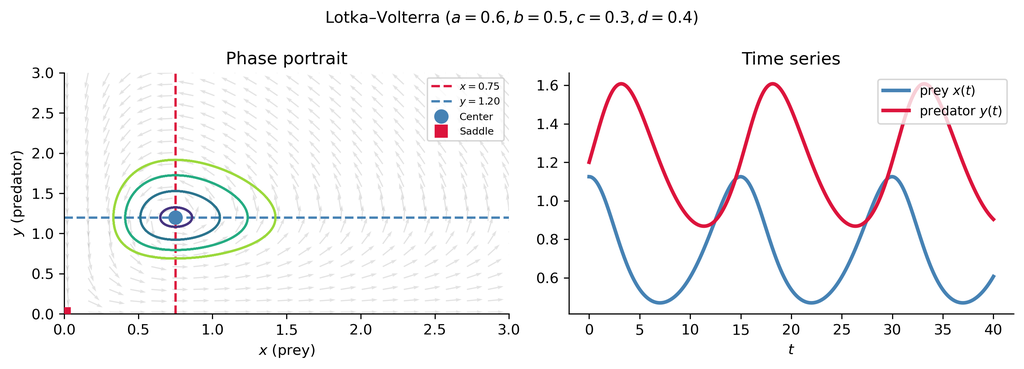

Figure 1

# Competing Species

## The Model

Two species compete for the same resource. Logistic growth with interspecific competition:

$$x' = x(a_1 - b_1 x - c_1 y), \qquad y' = y(a_2 - b_2 y - c_2 x).$$

Four critical points:

| Equilibrium | Meaning |
| --- | --- |
| $(0,0)$ | Both extinct (always unstable) |
| $(a_1/b_1,\; 0)$ | $x$ alone at carrying capacity |
| $(0,\; a_2/b_2)$ | $y$ alone at carrying capacity |
| $(x^*,y^*)$ (interior) | Potential coexistence |

**Outcome depends on competition strengths** $c_1, c_2$ relative to $b_1, b_2$:

- **$c_1 c_2 < b_1 b_2$ (weak competition):** interior equilibrium is **stable** — coexistence.
- **$c_1 c_2 > b_1 b_2$ (strong competition):** interior equilibrium is a **saddle** — competitive exclusion; one species wins depending on initial conditions.

## Competing Species — Phase Portraits

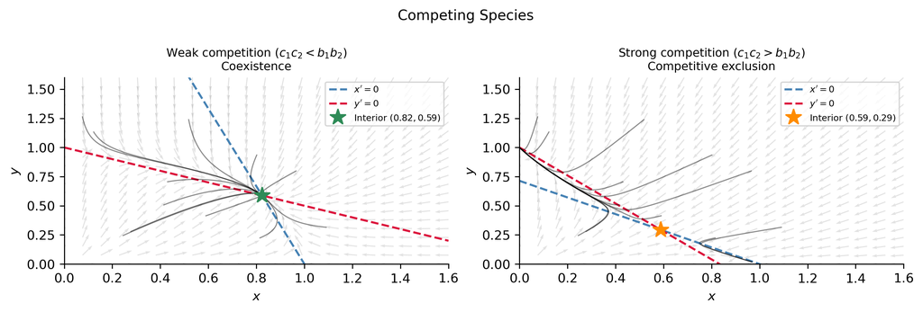

Figure 2

# SIR Epidemic Model

## The Model

Compartments: $S$ (susceptible), $I$ (infected), $R$ (removed). $N = S+I+R$ constant.

$$S' = -\beta SI, \quad I' = \beta SI - \gamma I, \quad R' = \gamma I. \tag{5.18--5.20}$$

| Parameter | Meaning |
| --- | --- |
| $\beta$ | Transmission rate (contacts × infection probability) |
| $\gamma$ | Recovery rate ($1/\gamma$ = mean infectious period) |

The 2D system $(S,I)$ is autonomous. From $I' = I(\beta S - \gamma)$:

- $I'>0$ (epidemic grows) $\iff$ $S > \gamma/\beta$.
- $I'<0$ (epidemic dies) $\iff$ $S < \gamma/\beta$.

## The Basic Reproduction Number $R_0$

At the start of an outbreak, $S \approx N$, so $I' \approx I(\beta N - \gamma)$.

**Basic Reproduction Number**

$$R_0 = \frac{\beta N}{\gamma}$$

= average number of secondary infections from one infected individual in a fully susceptible population.

$R_0 > 1$ | Epidemic occurs |  
$R_0 < 1$ | Infection dies out |  
$R_0 = 1$ | Threshold (endemic equilibrium) |

**Stability of disease-free state $(S^*, 0)$:**

$$J(S^*,0)=\begin{pmatrix}0 & -\beta S^* \\ 0 & \beta S^*-\gamma\end{pmatrix}, \quad \lambda_2 = \beta S^* - \gamma < 0 \iff R_0 < 1.$$

## SIR Phase Portrait and Time Series

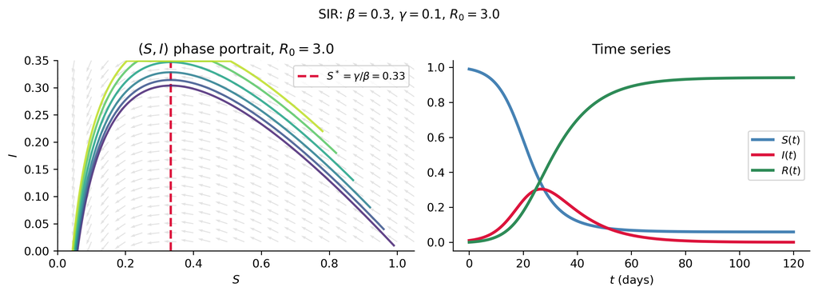

Figure 3

# Chemical Kinetics

## Law of Mass Action

The **law of mass action** states that the rate of a reaction is proportional to the product of the concentrations of the reacting species.

For consecutive reactions $A \xrightarrow{k_1} B \xrightarrow{k_2} C$, letting $x=[A]$ and $y=[B]$:

$$x' = -k_1 x, \qquad y' = k_1 x - k_2 y. \tag{5.21--5.22}$$

**Only equilibrium:** $(0,0)$ — all material converts to $C$.

$$J(0,0) = \begin{pmatrix}-k_1 & 0 \\ k_1 & -k_2\end{pmatrix}, \quad \lambda = -k_1,\,-k_2 < 0.$$

$\implies$ **Asymptotically stable node** — all concentrations approach chemical equilibrium.

**Analytical solution** (first equation decouples):

$$[A](t) = x_0 e^{-k_1 t}, \quad [B](t) = \frac{k_1 x_0}{k_2-k_1}\left(e^{-k_1 t}-e^{-k_2 t}\right), \quad [C]=x_0-x-y.$$

$[B]$ has a characteristic **intermediate peak** before decaying to zero.

## Chemical Kinetics — Plot

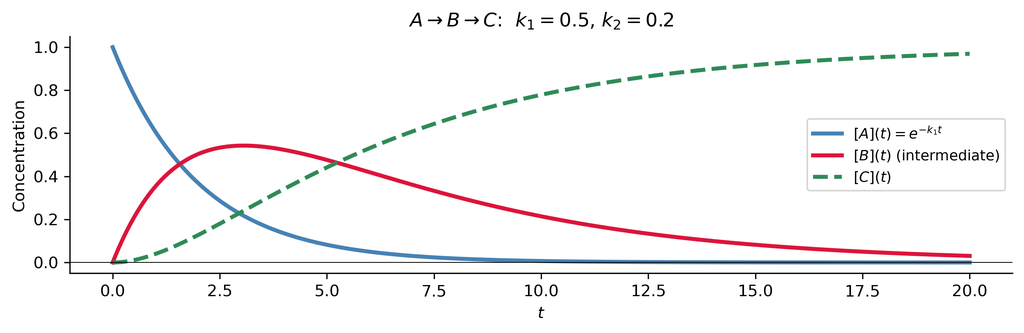

Figure 4

**Tip**

The **intermediate peak** in $[B](t)$ is a hallmark of consecutive reactions. Its height and time of occurrence depend on the ratio $k_1/k_2$.

# Nonlinear Pendulum

## The Model

Newton’s law for a pendulum: $\theta'' + \omega_0^2\sin\theta = 0$.

Let $x=\theta$, $y=\theta'$:

$$x' = y, \qquad y' = -\omega_0^2\sin x. \tag{5.23--5.24}$$

**Equilibria:** $y=0$ and $\sin x=0$, so $x=n\pi$.

**Jacobian:** $J(x,y) = \begin{pmatrix}0 & 1 \\ -\omega_0^2\cos x & 0\end{pmatrix}$.

| Equilibrium | $\cos x$ | $\lambda$ | Type |
| --- | --- | --- | --- |
| $(0,0),(2\pi,0),\ldots$ | $+1$ | $\pm i\omega_0$ | **Center** (pendulum down) |
| $(\pi,0),(3\pi,0),\ldots$ | $-1$ | $\pm\omega_0$ | **Saddle** (pendulum up) |

## Energy and the Separatrix

The system is **conservative** with energy

$$H(x,y) = \tfrac{1}{2}y^2 - \omega_0^2\cos x = \text{const.}$$

Orbits lie on level curves of $H$:

| Energy level | Orbit type | Motion |
| --- | --- | --- |
| $H < \omega_0^2$ | Closed | **Oscillation** (swings back and forth) |
| $H = \omega_0^2$ | **Separatrix** | Approaches inverted position asymptotically |
| $H > \omega_0^2$ | Open | **Full rotation** (swings over the top) |

The separatrix is the boundary between oscillatory and rotational motion. It passes through the saddle points $(\pm\pi, 0)$.

## Pendulum Phase Portrait

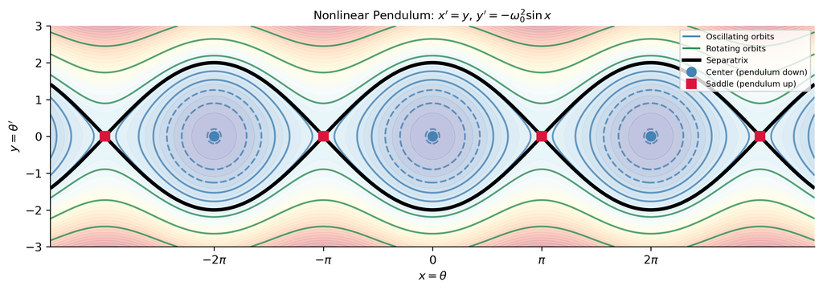

Figure 5

# Van der Pol Oscillator

## The Model

Nonlinear electronic circuit oscillator (van der Pol, 1926):

$$\mu'' - \varepsilon(1-\mu^2)\mu' + \mu = 0, \quad \varepsilon > 0.$$

Let $x=\mu$, $y=\mu'$:

$$x' = y, \qquad y' = \varepsilon(1-x^2)y - x. \tag{5.25--5.26}$$

**Nonlinear damping** $\varepsilon(1-x^2)y$:

- $|x|<1$: negative damping — **energy added** (system amplifies small oscillations)
- $|x|>1$: positive damping — **energy removed** (system suppresses large oscillations)

This self-regulating mechanism produces a **stable limit cycle** — all orbits converge to the same periodic orbit regardless of initial conditions.

## Critical Point Analysis

Only critical point: $(0,0)$.

$$J(0,0)=\begin{pmatrix}0&1\\-1&\varepsilon\end{pmatrix}, \quad \text{tr}\,J=\varepsilon>0, \quad \det J=1>0.$$

$\implies$ **Unstable spiral** (for small $\varepsilon$). Orbits spiral **outward** from the origin.

**Limit Cycle**

A **limit cycle** is an isolated closed orbit. The van der Pol system has a **stable (attracting) limit cycle**:

- Orbits inside the cycle spiral outward toward it.
- Orbits outside the cycle spiral inward toward it.
- This represents **self-sustained oscillations** — independent of initial conditions.

Limit cycles are a **purely nonlinear phenomenon**: they cannot exist in linear systems.

## Van der Pol Phase Portrait

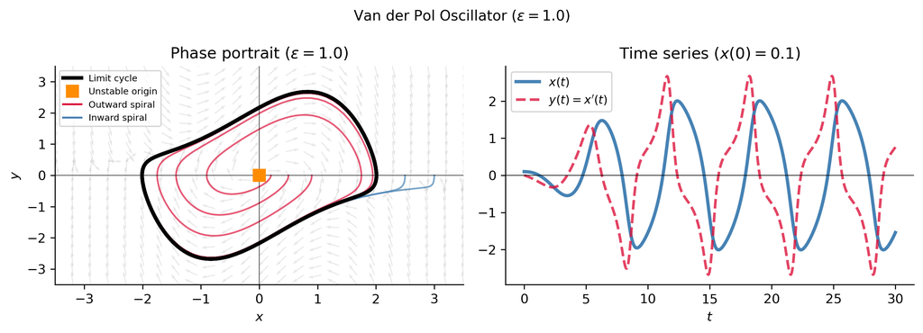

Figure 6

# Summary

## Key Takeaways

- **Lotka–Volterra:** the non-trivial equilibrium $(c/d,\, a/b)$ is a center for the linearization and a true center for the nonlinear system, confirmed by the conserved quantity $H = dx - c\ln x + by - a\ln y$. Both populations oscillate periodically.
- **Competing species:** if $c_1 c_2 < b_1 b_2$ (weak competition) the interior equilibrium is stable and both species coexist; if $c_1 c_2 > b_1 b_2$ (strong competition) the interior equilibrium is a saddle and competitive exclusion occurs — which species wins depends on initial conditions.
- **SIR epidemic:** the key quantity is the **basic reproduction number** $R_0 = \beta N/\gamma$. An epidemic occurs if and only if $R_0 > 1$. The disease-free equilibrium is stable when $R_0 < 1$, unstable when $R_0 > 1$.
- **Chemical kinetics:** consecutive reactions $A\to B\to C$ give an asymptotically stable node at the origin; the intermediate species $B$ exhibits a characteristic peak before decaying to zero.
- **Nonlinear pendulum:** centers at the downward equilibria and saddles at the inverted equilibria. The conserved energy $H = \tfrac{1}{2}y^2 - \omega_0^2\cos x$ gives the orbits; the separatrix ($H = \omega_0^2$) bounds oscillatory from rotational motion.
- **Van der Pol:** the origin is an unstable spiral; all orbits are attracted to a **stable limit cycle** — a purely nonlinear phenomenon representing self-sustained oscillations.

**Tip**

**Looking Ahead:** The existence of limit cycles and their stability is addressed by the **Poincaré–Bendixson theorem**, which provides criteria for when planar autonomous systems must have periodic orbits — a fundamental result in nonlinear dynamics.

**Note**

**Next:** Numerical methods — Logan §6.2.

## References

Logan, J David. 2015. *A First Course in Differential Equations, Third Edition*.